# The Impact of Celebrity Reviewers on Businesses

author: Bobby Tan date: November 20, 2015

# Celebrity Reviewers vs Businesses

- We study of the impact of Celebrity Yelp Reviewers on Businesses.
- Why should you be interested in the data?
- Businesses owners want to know if attracting celebrities will benefit their businesses
- Marketing teams can their adapt strategies
- Who are the celebrity reviewers? +Top 10 percent of cumulative votes received

# About Celebrity Yelp Reviewers

- They are prolific +Celebrities generate 37.3866348 percent of all reviews.
- They command exponentially more votes than the lowes decile of yelp users.

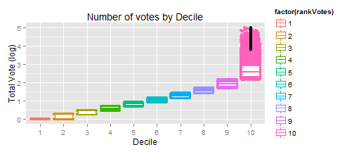

# Results 1

- A random sample of reviews the same size as the celebrity group is selected.
- Acts as control group
- Represents the “average” yelp review
- Both groups turn out to be very similar
- both have mean review scores ~3.7
- mean checkins of 151(celebrity) vs 146 (control)
- Unpaired t tests reveal differences are not statistically significant.

# Results 2 and Conclusion

- Comparison of checkins by review scores also well within the error bars of each other.

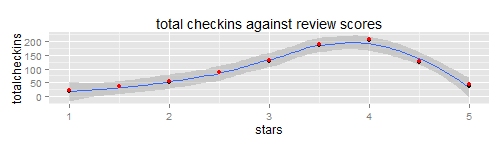

- The number of reviews did not change significantly in the 3 months before and after a yelp review.
- Conclusion: Celebrity reviewers’ individual reviews do not impact businesses more significantly than the average yelp review.